# Transfer Analysis

Nathan Matten

2022-11-17

```r
library(tidyverse)
library(toRvik)
library(caret)
library(corrplot)
```

# 1 Data Loading and Wrangling

## 1.1 Data Loading

### 1.1.1 Transfer Players dataframe

The code below creates the transfer_players dataset, as well as removes the players that transferred to and from outside d1

```r
transfer_players <- transfer_portal(year = 2017) %>%
  rbind(transfer_portal(year = 2018)) %>%
  rbind(transfer_portal(year = 2019)) %>%
  rbind(transfer_portal(year = 2020)) %>%
  rbind(transfer_portal(year = 2021)) %>%
  rbind(transfer_portal(year = 2022)) %>%
  select(-source) %>%
  filter(from_d1 == TRUE, to_d1 == TRUE)
# Removed players that transferred to and from outside D1 -- I don't believe they're part of our study currently (but they can definitely be added back in)... although this removes about 900 player transfers
```

### 1.1.2 Player stats dataframe

We now create a giant player_stats table with all players from seasons 2015 through 2022

```r
player_stats <- bart_player_season(year = 2017, stat = 'all') %>%
  rbind(bart_player_season(year = 2018, stat = 'all')) %>%
  rbind(bart_player_season(year = 2019, stat = 'all')) %>%
  rbind(bart_player_season(year = 2020, stat = 'all')) %>%
  rbind(bart_player_season(year = 2021, stat = 'all')) %>%
  rbind(bart_player_season(year = 2022, stat = 'all')) %>%
  rbind(bart_player_season(year = 2016, stat = 'all')) %>%
  rbind(bart_player_season(year = 2015, stat = 'all'))
```

### 1.1.3 Conference Ratings Dataframe

In order to calculate the conf_diff stat, we need a dataframe with the conference ratings. That is created below.

```r
conf_ratings <- read.csv(file = "~/Documents/GitHub/Transfer_Data_Pitt/kenpom_ratings_16_22.csv")
colnames(conf_ratings) <- c("Conference","2016","2017","2018","2019","2020","2021","2022")
conf_ratings$Conference[conf_ratings$Conference == "Horizon"] <- "Horz"
conf_ratings$Conference[conf_ratings$Conference == "Sun Belt"] <- "SB"
conf_ratings$Conference[conf_ratings$Conference == "Big East"] <- "BE"
conf_ratings$Conference[conf_ratings$Conference == "Big West"] <- "BW"
conf_ratings$Conference[conf_ratings$Conference == "Big Sky"] <- "BSky"
conf_ratings$Conference[conf_ratings$Conference == "Atlantic 10"] <- "A10"
conf_ratings$Conference[conf_ratings$Conference == "Northeast"] <- "NEC"
conf_ratings$Conference[conf_ratings$Conference == "American East"] <- "AE"
conf_ratings$Conference[conf_ratings$Conference == "Patriot"] <- "Pat"
conf_ratings$Conference[conf_ratings$Conference == "Southern"] <- "SC"
conf_ratings$Conference[conf_ratings$Conference == "Summit"] <- "Sum"
conf_ratings$Conference[conf_ratings$Conference == "Big 12"] <- "B12"
conf_ratings$Conference[conf_ratings$Conference == "C-USA"] <- "CUSA"
conf_ratings$Conference[conf_ratings$Conference == "Big 10"] <- "B10"
conf_ratings$Conference[conf_ratings$Conference == "Big South"] <- "BSth"
conf_ratings$Conference[conf_ratings$Conference == "Southland"] <- "Slnd"
conf_ratings$Conference[conf_ratings$Conference == "ASUN"] <- "ASun"
conf_ratings$Conference[conf_ratings$Conference == "Ohio Valley"] <- "OVC"
conf_ratings$Conference[conf_ratings$Conference == "Pac 12"] <- "P12"
conf_ratings$Conference[conf_ratings$Conference == "AAC"] <- "Amer"
```

## 1.2 Data Wrangling/Merging

### 1.2.1 Data Set for transferred players

Working through merging tables to create a master table with all stats for transfer players from the season before they transferred to the season after transfer.

```r
player_stats <- player_stats %>%
  dplyr::select(id,player,team,conf,g,year,usg,ortg,efg,ts,ftm,fta,ft_pct,two_m,two_a,two_pct,three_m,three_a,three_pct,oreb_rate,dreb_rate,bpm,ast,ast_to,to,blk,stl)
team_mapping <- unique(player_stats[,c("team", "conf")]) %>%
  arrange(conf, team)
transfer_players <- merge(transfer_players, team_mapping, by.x = "from", by.y = "team", all.x = TRUE, all.y = FALSE) %>%
  select(-c(exp, from_d1, to_d1))
transfer_players <- merge(transfer_players, team_mapping, by.x = "to", by.y = "team", all.x = TRUE, all.y = FALSE)
transfer_players <- transfer_players %>%
  mutate(old_conf = conf.x) %>%
  mutate(new_conf = conf.y) %>%
  select(id,player,year,from,old_conf,to,new_conf,imm_elig,sit) %>%
  arrange(year,old_conf,new_conf,player)
temp <- merge(transfer_players,player_stats, by.x = "id", by.y = "id", all.x = TRUE)  %>%
  filter(year.x == year.y, team == to.x, conf == new_conf)  %>%
  arrange(id, old_conf, year.x, year.y, new_conf) %>%
  distinct
temp_1 <- merge(transfer_players,player_stats, by.x = "id", by.y = "id", all.x = TRUE)  %>%
  mutate("year_1" = year.x -1) %>%
  filter(year_1 == year.y, team == from, conf == old_conf)  %>%
  arrange(id, old_conf, year.x, year.y, new_conf) %>%
  select(-"year_1") %>%
  distinct
temp_2 <- merge(transfer_players,player_stats, by.x = "id", by.y = "id", all.x = TRUE)  %>%
  mutate("year_2" = year.x - 2) %>%
  filter(year_2 == year.y, team == from, conf == old_conf)  %>%
  arrange(id, old_conf, year.x, year.y, new_conf) %>%
  select(-"year_2") %>%
  distinct
temp.1 <- merge(transfer_players,player_stats, by.x = "id", by.y = "id", all.x = TRUE)  %>%
  mutate("year1" = year.x + 1) %>%
  filter(year1 == year.y, team == to.x, conf == new_conf)  %>%
  arrange(id, old_conf, year.x, year.y, new_conf) %>%
  select(-"year1") %>%
  distinct
temp2 <- rbind(temp,temp_1,temp_2,temp.1) %>%
  arrange(id, old_conf, year.x, year.y, new_conf)
temp_post <- temp2 %>%
  group_by(id) %>%
  arrange(id, desc(year.y)) %>%
  filter(to.x == team) %>%
  dplyr::slice(1) %>%
  ungroup()
temp_pre <- temp2 %>%
  group_by(id) %>%
  arrange(id, desc(year.y)) %>%
  filter(to.x != team) %>%
  dplyr::slice(1) %>%
  ungroup()
diff1 <- setdiff(temp_pre$id,temp_post$id)
diff2 <- setdiff(temp_post$id, temp_pre$id)
missing <- rbind(transfer_players[transfer_players$id %in% diff1,],transfer_players[transfer_players$id %in% diff2,])
missing <-  (missing$id)
for (i in 1:length(missing)){
  temp_pre <- subset(temp_pre, temp_pre$id != missing[i])
  temp_post <- subset(temp_post, temp_post$id != missing[i])
}
temp2 <- cbind(temp_pre,temp_post)
diff3 <- setdiff(transfer_players$id,temp2$id)
length(diff3)
master <- temp2
```

### 1.2.2 Final Data Set

Consolidating the master table into the stats we will want to use, as well as creating the conf_diff stat

```r
#Creating final dataset
transfer_stats <- master[,c(1:9,11:18,28:35,46:49,65)]
colnames(transfer_stats) <- c("id","player","tran_year","from_uni","old_conf","to_uni","new_conf","imm_elig","sit","team","conf","g","from_year","usg","ortg","efg","ts","oreb_rate","dreb_rate","bpm","ast_rate","ast_to","to_rate","blk_rate","stl_rate","new_team","conf2","g2","a_year","bpm2")
transfer_stats <- transfer_stats %>%  filter(from_year != 2015)
# Retrieving conference differences (multiple steps)
# 1: Getting old conference kenpom rating
transfer_stats <- merge(transfer_stats, conf_ratings, by.x = "old_conf", by.y = "Conference", all.x = TRUE, all.y = FALSE)
temp4 <- transfer_stats[,c(3,13,31:37)]
temp_col <- temp4$from_year
for(i in 1:length(temp_col)){
    temp_col[i] <- temp4[1,grepl(temp_col[i], colnames(temp4))]
}
ratings <- matrix()
ratings$ratings_old <- temp_col
# 2: Getting new conference kenpom rating
transfer_stats <- transfer_stats[,c(1:30)]
transfer_stats <-  merge(transfer_stats, conf_ratings, by.x = "conf2", by.y = "Conference", all.x = TRUE, all.y = FALSE)
temp5 <- transfer_stats[,c(29,31:37)]
temp_col <- temp5$a_year
for(i in 1:length(temp_col)){
    temp_col[i] <- temp5[1,grepl(temp_col[i], colnames(temp5))]
}
ratings$ratings_new <- temp_col
remove(temp4)
remove(temp5)
ratings <- ratings[-1]
# 3: Getting difference from new conference to old conference and adding to dataset
ratings$diff <- ratings$ratings_old - ratings$ratings_new
transfer_stats <- transfer_stats[,c(1:30)]
transfer_stats$conf_diff <- ratings$diff
# Final dataset with only number values
final_stats <- transfer_stats[,c(13,15:22,24:26,30,31,1:3)]
```

# 2 Analysis

## 2.1 Model Selection

### 2.1.1 Correlation

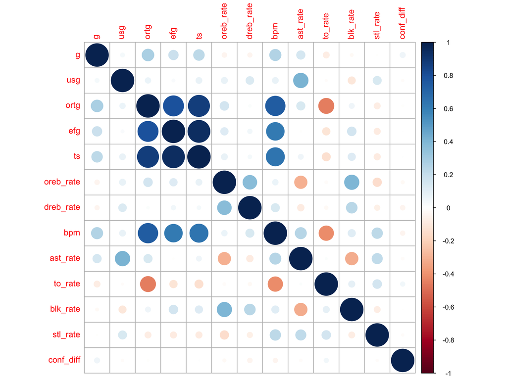

```r
corrplot(cor(final_stats[,c(1:12,14)]))
```

It appears that TS, eFg, and ortg are all highly correlated (as expected), and we should remove all but 1 of them. I believe we should either use TS or ortg, but it looks like ortg is negatively related to to_rate, so let’s go with TS%.

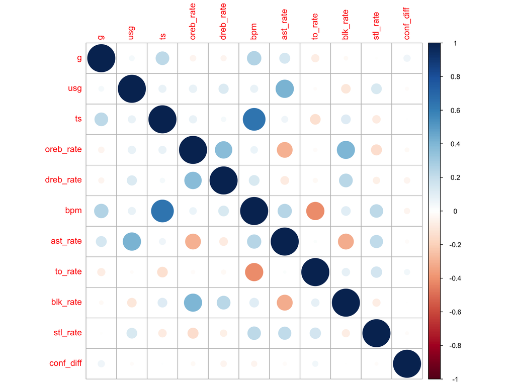

```r
corrplot(cor(final_stats[,c(1,2,5:12,14)]))
```

TS and BPM are both still related, but I think it’s small enough that we can move forward with additional selection

### 2.1.2 AIC Predictor selection

```r
library(MASS)
dat_reg <- final_stats %>% dplyr::select(g,usg,ts,oreb_rate,dreb_rate,bpm,ast_rate,to_rate,blk_rate,stl_rate,bpm2,conf_diff)
indexes <- createDataPartition(dat_reg$bpm2, p = .8, list = F)
train <- dat_reg[indexes, ]
test <- dat_reg[-indexes, ]
indexes2 <-  createDataPartition(train$bpm2, p = .76, list = F)
validate <- train[-indexes2,]
train <- train[indexes2,]

train_x <- train[,c(1,2,3,6)]
train_y <- train[,11]

validate_x <- validate[,c(1,2,3,6)]
validate_y <- validate[,11]

test_x <- test[,c(1,2,3,6)]
test_y <- test[,11]

full.fit <- lm(bpm2 ~ ., data = train)
base.fit <- lm(bpm2 ~ 1, data=train)
summary(full.fit)
# Just based on full fit, it appears, that the variables we should keep are g, usg, ts, bpm, and maybe stl_rate...
fit.aic <- stepAIC(base.fit, direction = 'both', scope = list(upper = full.fit, lower = base.fit))
fit.aic2 <- stepAIC(full.fit, direction = 'both', scope = list(upper = full.fit, lower = base.fit))
# It appears that AIC fit has the same 5 predictors mentioned above...
# We can also add dreb_rate... but it would appear that conf_diff is not significant regardless
mod1 <- lm(bpm2 ~ bpm + g + usg + ts, data = train)
mod2 <- lm(bpm2 ~ bpm + g + usg + ts + stl_rate, data = train)
mod3 <- lm(bpm2 ~ bpm + g + usg + ts + stl_rate + dreb_rate, data = train)
mod4 <- lm(bpm2 ~ bpm + g + usg + ts + stl_rate + dreb_rate + ast_rate, data = train)
mod5 <- lm(bpm2 ~ bpm + g + usg + ts + stl_rate + dreb_rate + ast_rate + blk_rate, data = train)
mod6 <- lm(bpm2 ~ bpm + g + usg + ts + stl_rate + blk_rate + to_rate, data = train)
mod7 <- lm(bpm2 ~ bpm + g + usg + ts + conf_diff, data = train)
mod8 <- lm(bpm2 ~ bpm + g + usg + ts + stl_rate + conf_diff, data = train)
mod9 <- lm(bpm2 ~ bpm + g + usg + ts + stl_rate + dreb_rate + conf_diff, data = train)
mod10 <- lm(bpm2 ~ bpm + g + usg + ts + stl_rate + dreb_rate + ast_rate + conf_diff, data = train)
mod11 <- lm(bpm2 ~ bpm + g + usg + ts + stl_rate + dreb_rate + ast_rate + blk_rate + conf_diff, data = train)
mod12 <- lm(bpm2 ~ bpm + g + usg + ts + stl_rate + blk_rate + to_rate + conf_diff, data = train)
aics <- AIC(mod1,mod2,mod3,mod4,mod5,mod6,mod7,mod8,mod9,mod10,mod11,mod12)
fitted <- data.frame(matrix(ncol=12,nrow=nrow(validate)))
colnames(fitted) <- c("mod1","mod2","mod3","mod4","mod5","mod6","mod7","mod8","mod9","mod10","mod11","mod12")
fitted[,1] <- predict(mod1, validate)
fitted[,2] <- predict(mod2, validate)
fitted[,3] <- predict(mod3, validate)
fitted[,4] <- predict(mod4, validate)
fitted[,5] <- predict(mod5, validate)
fitted[,6] <- predict(mod6, validate)
fitted[,7] <- predict(mod7, validate)
fitted[,8] <- predict(mod8, validate)
fitted[,9] <- predict(mod9, validate)
fitted[,10] <- predict(mod10, validate)
fitted[,11] <- predict(mod11, validate)
fitted[,12] <- predict(mod12, validate)

# The AIC is really high regardless, but mod2 and 3 are the best... I think mod3 is the best option for now
mod_rmse <- data.frame(matrix(ncol=2,nrow=12))
colnames(mod_rmse) <- c("Model Number","RMSE")
for(i in 1:12){
  mod_rmse[i,1] <- i
  mod_rmse[i,2] <-  round(caret::RMSE(validate$bpm2,fitted[,i]),4)
}
#mod_rmse %>% arrange(RMSE)
# Either model 2 or 7...
test_fit <- data.frame(matrix(ncol=2,nrow=nrow(test)))
colnames(test_fit) <- c("mod1","mod7")
test_fit[,1] <- predict(mod1, test)
test_fit[,2] <- predict(mod7, test)
mod_rmse_test <- data.frame(matrix(ncol=2,nrow=2))
colnames(mod_rmse_test) <- c("Model Number","RMSE")
for(i in 1:2){
  mod_rmse_test[i,2] <-  round(caret::RMSE(test$bpm2,fitted[,i]),4)
}
mod_rmse_test[,1] <- c(1,7)
# Based on the test set, model 1 is better
```

We tested 12 different models with different variables to see which one is the best and confirm our AIC selection. The variables included were:

| Model | bpm | g | usg | ts | stl_rate | dreb_rate | ast_rate | blk_rate | to_rate | conf_diff | RMSE |
| --- | --- | --- | --- | --- | --- | --- | --- | --- | --- | --- | --- |
| mod1 | $\checkmark$ | $\checkmark$ | $\checkmark$ | $\checkmark$ |  |  |  |  |  |  | 7.4156 |
| mod2 | $\checkmark$ | $\checkmark$ | $\checkmark$ | $\checkmark$ | $\checkmark$ |  |  |  |  |  | 7.4162 |
| mod3 | $\checkmark$ | $\checkmark$ | $\checkmark$ | $\checkmark$ | $\checkmark$ | $\checkmark$ |  |  |  |  | 7.4233 |
| mod4 | $\checkmark$ | $\checkmark$ | $\checkmark$ | $\checkmark$ | $\checkmark$ | $\checkmark$ | $\checkmark$ |  |  |  | 7.4202 |
| mod5 | $\checkmark$ | $\checkmark$ | $\checkmark$ | $\checkmark$ | $\checkmark$ | $\checkmark$ | $\checkmark$ | $\checkmark$ |  |  | 7.4453 |
| mod6 | $\checkmark$ | $\checkmark$ | $\checkmark$ | $\checkmark$ | $\checkmark$ |  |  | $\checkmark$ | $\checkmark$ |  | 7.446 |
| mod7 | $\checkmark$ | $\checkmark$ | $\checkmark$ | $\checkmark$ |  |  |  |  |  | $\checkmark$ | 7.4209 |
| mod8 | $\checkmark$ | $\checkmark$ | $\checkmark$ | $\checkmark$ | $\checkmark$ |  |  |  |  | $\checkmark$ | 7.4214 |
| mod9 | $\checkmark$ | $\checkmark$ | $\checkmark$ | $\checkmark$ | $\checkmark$ | $\checkmark$ |  |  |  | $\checkmark$ | 7.428 |
| mod10 | $\checkmark$ | $\checkmark$ | $\checkmark$ | $\checkmark$ | $\checkmark$ | $\checkmark$ | $\checkmark$ |  |  | $\checkmark$ | 7.425 |
| mod11 | $\checkmark$ | $\checkmark$ | $\checkmark$ | $\checkmark$ | $\checkmark$ | $\checkmark$ | $\checkmark$ | $\checkmark$ |  | $\checkmark$ | 7.45 |
| mod12 | $\checkmark$ | $\checkmark$ | $\checkmark$ | $\checkmark$ | $\checkmark$ |  |  | $\checkmark$ | $\checkmark$ | $\checkmark$ | 7.4507 |

The AIC values from models 1:12 are:

|  | df | AIC |
| --- | --- | --- |
| mod1 | 6 | 8004.884 |
| mod2 | 7 | 8002.976 |
| mod3 | 8 | 8004.752 |
| mod4 | 9 | 8006.499 |
| mod5 | 10 | 8006.231 |
| mod6 | 9 | 8003.667 |
| mod7 | 7 | 8006.714 |
| mod8 | 8 | 8004.805 |
| mod9 | 9 | 8006.595 |
| mod10 | 10 | 8008.338 |
| mod11 | 11 | 8008.074 |
| mod12 | 10 | 8005.517 |

The RMSE from mod1 for the validation set is 7.4156

### 2.1.3 KNN Choose k

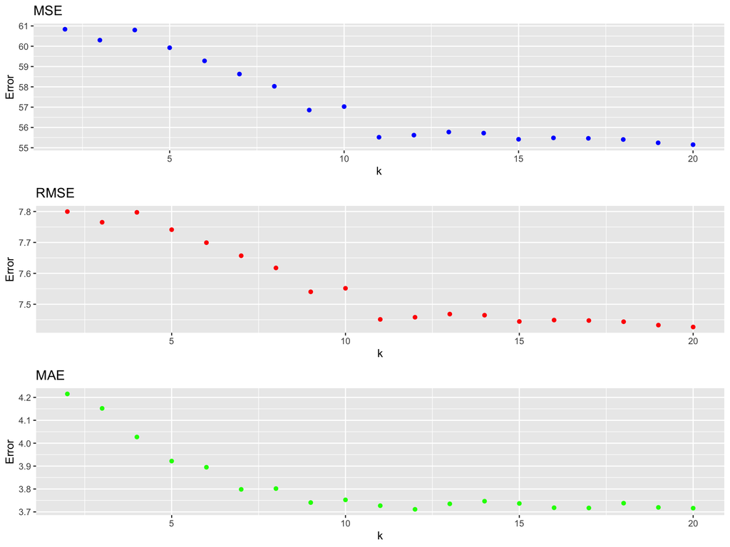

```r
# Now choose k
output <- data.frame(matrix(ncol=4,nrow=19))
colnames(output) <- c('MSE','MAE','RMSE','k')
# for loop to print knnreg results based on k=2:10
for (i in 2:20){
  knnmodel = knnreg(train_x,train_y,k=i)
  #cat(knnmodel,i)
  pred_y <- predict(knnmodel, data.frame(validate_x))
  #cat(pred_y,i)
  output[i-1,4] <- i
  output[i-1,1] <- round(mean((validate_y - pred_y)^2),4)
  output[i-1,2] <- round(caret::MAE(validate_y,pred_y),4)
  output[i-1,3] <- round(caret::RMSE(validate_y,pred_y),4)
  cat("KNN Model", i, ": BPM Prediction","MSE: ", output[i-1,1], "MAE: ", output[i-1,2], " RMSE: ", output[i-1,3], '\n')
}
p_mse_1 <- ggplot(data = output) +
  geom_point(aes(x = k, y = MSE), color = 'blue', show.legend = FALSE) +
  xlab("k") +
  ylab("Error") +
  ggtitle("MSE")
p_rmse_1 <- ggplot(data = output) +
  geom_point(aes(x = k, y= RMSE), color = 'red', show.legend = FALSE) +
  xlab("k") +
  ylab("Error") +
  ggtitle("RMSE")
p_mae_1 <- ggplot(data = output) +
  geom_point(aes(x = k, y = MAE), color = 'green', show.legend = FALSE) +
  xlab("k") +
  ylab("Error") +
  ggtitle("MAE")
mins <- apply(output[,1:3], 2, min)
which(output[,1] == mins[1])
which(output[,2] == mins[2])
which(output[,3] == mins[3])
# Looks like k = 19 is the best... but that seems a bit high...
# k = 9 or k = 11 are local mins, so let's use one of those in additional analysis... I choose 9
library(gridExtra)
grid.arrange(p_mse_1,p_rmse_1,p_mae_1, nrow = 3)
```

| MSE | MAE | RMSE | k |
| --- | --- | --- | --- |
| 60.8362 | 4.2152 | 7.7998 | 2 |
| 60.3005 | 4.1521 | 7.7653 | 3 |
| 60.7990 | 4.0271 | 7.7974 | 4 |
| 59.9270 | 3.9220 | 7.7413 | 5 |
| 59.2789 | 3.8950 | 7.6993 | 6 |
| 58.6300 | 3.7984 | 7.6570 | 7 |
| 58.0274 | 3.8018 | 7.6176 | 8 |
| 56.8566 | 3.7408 | 7.5403 | 9 |
| 57.0275 | 3.7525 | 7.5517 | 10 |
| 55.5186 | 3.7271 | 7.4511 | 11 |
| 55.6210 | 3.7112 | 7.4580 | 12 |
| 55.7751 | 3.7352 | 7.4683 | 13 |
| 55.7213 | 3.7468 | 7.4647 | 14 |
| 55.4175 | 3.7368 | 7.4443 | 15 |
| 55.4855 | 3.7182 | 7.4489 | 16 |
| 55.4645 | 3.7172 | 7.4474 | 17 |
| 55.4068 | 3.7381 | 7.4436 | 18 |
| 55.2439 | 3.7196 | 7.4326 | 19 |
| 55.1525 | 3.7163 | 7.4265 | 20 |

## 2.2 Additional analysis methods

### 2.2.1 LOOCV

In order to minimize RMSE, we will try using the “Leave one out” cross-validation technique (through the built in r function). We will also run a manual version of LOO in subsequent blocks.

```r
ctrl <- trainControl(method = "LOOCV")
mod_loocv <- train(bpm2 ~ bpm + g + usg + ts, data = dat_reg, method = "lm", trControl = ctrl)
```

The RMSE from the internal LOOCV function is 6.4142

### 2.2.2 LOO

```r
tran_loo <- dat_reg[,c(1,2,3,6,11)]
response_loo <- data.frame(matrix(ncol=4))
colnames(response_loo) <- c('ID','bpm2','Pred_BPM2','bpm2_diff')
for (i in 1:nrow(tran_loo)){
  train_loo <- tran_loo[-i,]
  test_loo <- tran_loo[i,c(1:4)]
  test_loo_y <- tran_loo[i,5]
  lmmodel = lm(bpm2 ~ bpm + ts + g + usg, data = train_loo)
  pred_y <- predict(lmmodel, data.frame(test_loo))
  response_loo[i,3] <- pred_y
  response_loo[i,2] <- test_loo_y
  response_loo[i,1] <- i
  response_loo[i,4] <- test_loo_y - pred_y
}
RMSE_loo <- caret::RMSE(response_loo$bpm2,response_loo$Pred_BPM2)
```

The RMSE of self-implemented “leave one out” is: 6.4142. This is the same as LOOCV function (which it should be - so it appears that I’m doing it correctly).

### 2.2.3 LOO KNN

```r
tran_loo_k <- dat_reg[,c(1,2,3,6,11)]
response_loo_k <- data.frame(matrix(ncol=4))
colnames(response_loo_k) <- c('ID','bpm2','Pred_BPM2','bpm2_diff')
for (i in 1:nrow(tran_loo_k)){
  train_loo_k <- tran_loo_k[-i,c(1:4)]
  train_loo_yk <- tran_loo_k[-i,5]
  test_loo_k <- tran_loo_k[i,c(1:4)]
  test_loo_yk <- tran_loo_k[i,5]
  knn_loo <- knnreg(train_loo_k,train_loo_yk,k=11)
  pred_yk <- predict(knn_loo, test_loo_k)
  response_loo_k[i,3] <- pred_yk
  response_loo_k[i,2] <- test_loo_yk
  response_loo_k[i,1] <- i
  response_loo_k[i,4] <- test_loo_yk - pred_yk
}
RMSE_loo_k <- caret::RMSE(response_loo_k$bpm2,response_loo_k$Pred_BPM2)
```

The RMSE of self-implemented “leave one out KNN regression” is: 6.5418

### 2.2.4 Extreme Gradient Boost analysis

```r
library(xgboost)
xgb_train = xgb.DMatrix(data = as.matrix(train_x), label = train_y)
xgb_test = xgb.DMatrix(data = as.matrix(test_x), label = test_y)
xgbc = xgboost(data = xgb_train, max.depth = 2, nrounds = 50)
pred_yx = predict(xgbc, xgb_test)
rmsex = caret::RMSE(test_y, pred_yx)
```

The RMSE of extreme gradient boosting training is 8.6465. It appears that the LOOCV is the best, followed by LOO-KNN, RMSE of the basic model (mod1), KNN, and finally XGBT.

# 3 Predictive Function

## 3.1 Writing the function

```r
bpm_pred_name <- function(years = current_season(), id = NULL, name = NULL){
  require(toRvik)
    players <- bart_players(year = years)
  specific_player <- players[which((players$player == name) & players$year == years),]
  stats_hold <- bart_player_season(year = years, id = specific_player$id, stat = 'all')
  bpm2 <- mod1$coefficients[1] + mod1$coefficients[2]*stats_hold$bpm + mod1$coefficients[3]*stats_hold$g + mod1$coefficients[4]*stats_hold$usg + mod1$coefficients[5]*stats_hold$ts
  unlist(bpm2)
  if(nrow(specific_player) == 0){
    return("This player did not play that year")
  }
  else{return(cat(as.double(bpm2)))}
  }
bpm_pred_stats <- function(bpm = NULL, g = NULL, usg = NULL, ts = NULL){
  require(toRvik)
  bpm2 <- mod1$coefficients[1] + mod1$coefficients[2]*bpm + mod1$coefficients[3]*g + mod1$coefficients[4]*usg + mod1$coefficients[5]*ts
    return(cat(as.double(bpm2)))
  }
bpm_pred_name(years = 2022, name = "Baylor Scheierman")

bpm_pred_stats(7.53,33,22.6,64.3)
```

This function can now take the input of a specific year and a player name and return their predicted BPM based on transfer data… I’m curious what would happen if I added in conf_diff as a predictor and how to calculate on the fly, but that can be a future question. One of my other questions is should I do prediction without the previous year’s BPM? That might be drastically skewing the results.